# Effect of Water Stress Treatment on Growth Parameters

1. Sunday Ojo 2. Alphonsa Baby 3. Susmita Sigdel

2023-01-21

# Title: Comparative study of effect of water stress in different growth parameters of cultivated crops and wild weed species

# Introduction

Water stress affects plant growth and development, including plant height, leaf length, width, dry matter, and chlorophyll content (Picón-Toro et al., 2012). Leaves are essential indicators of growth and yield since they play a significant role in physiological processes (Zhang et al., 2015). The plant’s main response to water stress is to reduce its plant height, leaf area with increasing leaf numbers and thus improve water use efficiency (Ramezanifar et al., 2022). Photosynthesis is increased by higher chlorophyll levels and chlorophyll levels are higher in plants that are more resilient to water stress (Jangpromma et al., 2010).The chlorophyll content is a proxy for overall photosynthetic efficiency in plants and therefore is a good indicator of water stress tolerance in crop species (Hasanuzzaman et al., 2022).

# Objectives

To know the response of different cultivated and wild species to the water stress To know the effect of water stress on different growth parameters of cultivated and wild species

## Learning Objectives

The main objective of this project is to get familiar with the R coding and use the R for the analysis of biological data.

## Hypothesis

1. Ho = There will be no significant difference in the growth parameter of plants due to water stress
2. H1 = There will be significant difference in the growth parameter of plants due to water stress

# Materials and Methods

## 2.2 Measured Parameters

WET Sensor was used to monitor electrical conductivity and soil humidity. Electrical conductivity was measured in milli Siemens per centimeters (mS/cm) and soil humidity was recorded in percentages. Using a SPAD meter, the amount of chlorophyll was calculated in micromoles per square meter (mmolem-2). Using a digimizer, we measured the length of the roots and the area of the leaves. Fresh weight was calculated using a weighing machine and the dry weight was calculated after the contents had been dried in the oven for more than 24 hours.

## 2.3 Statistical Analysis

Google Sheet was used to enter the data. All statistical analysis was conducted in R Studio version 4.2.1. Parametric data that meet the assumption of the analysis of variance were subjected to factorial analysis of variance (ANOVA) using the linear mixed model. Model residuals were checked for normality using the shapiro Test. Post hoc means separation was achieved using Tukey Honestly significant difference (TukeyHSD) with the aid of the agricolae package in R. Missing data were drop or imputed using column means prior to analysis.

# Import and tidy the data

```
## [1] "https://docs.google.com/spreadsheets/\n#d/1WM6hDgwCFxbLpT37HLzU-iYZAEGBdHP6CpU8BDwWmZc"
```

```
## [1] "W1" "W2" "W3" "W4" "W5" "W6"
```

# Variation of some variables accross weeks

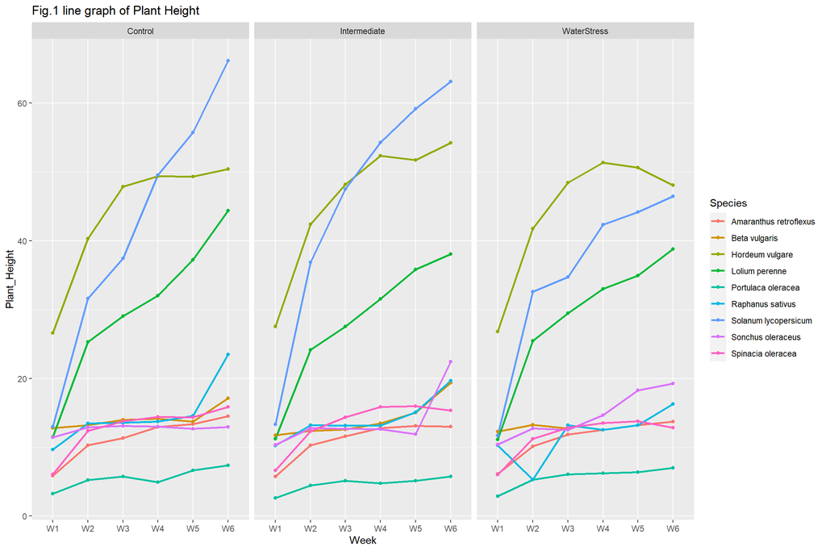

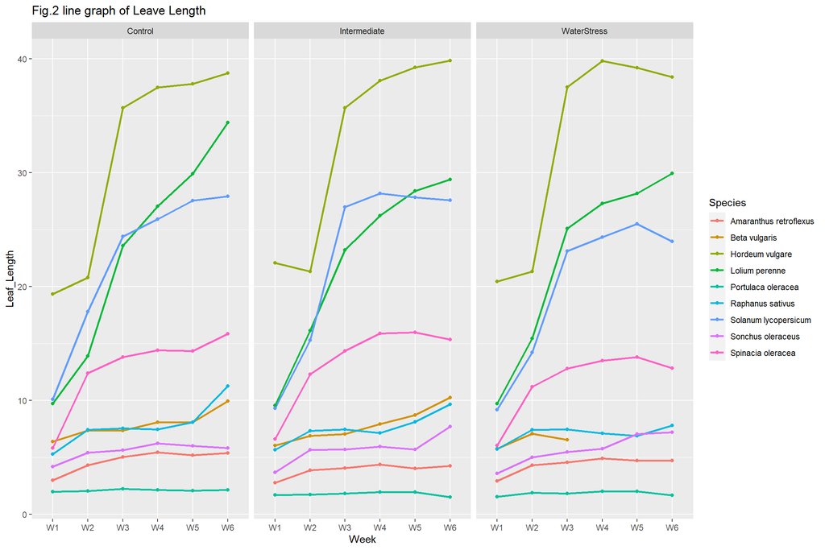

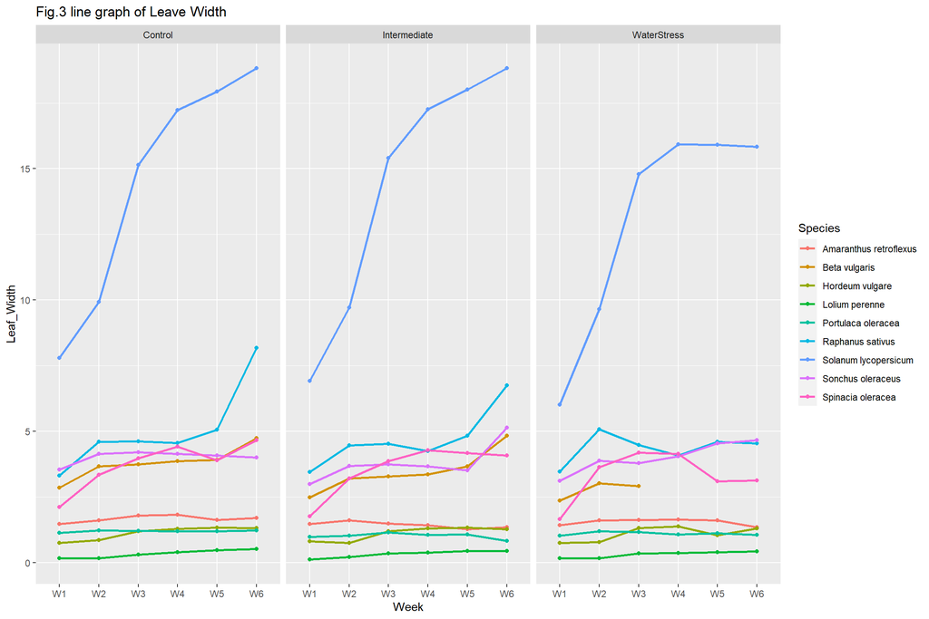

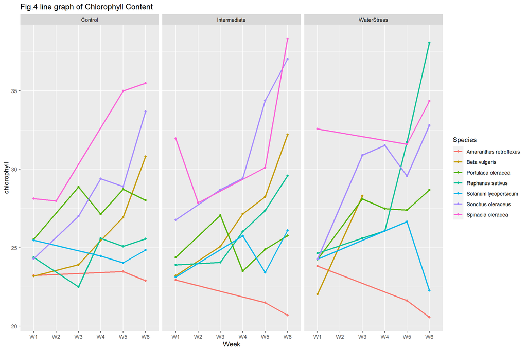

# Principal component analysis

# Scree Plot

The Eigenvalues are shown visually in the scree plot. The graph was created to show how many significant elements there were in the datasets. In this instance, the first two principal components together account for more than 60%. As a result, just the first “major component” was chosen to be taken into consideration when looking at the factors that best explain the water stress that the plants experienced.

```
##       eigenvalue variance.percent cumulative.variance.percent
## Dim.1 4.81913983       53.5459981                    53.54600
## Dim.2 1.18738796       13.1931996                    66.73920
## Dim.3 0.97732119       10.8591244                    77.59832
## Dim.4 0.77615643        8.6239604                    86.22228
## Dim.5 0.53496641        5.9440712                    92.16635
## Dim.6 0.29996500        3.3329444                    95.49930
## Dim.7 0.26478232        2.9420258                    98.44132
## Dim.8 0.07104183        0.7893537                    99.23068
## Dim.9 0.06923903        0.7693225                   100.00000
```

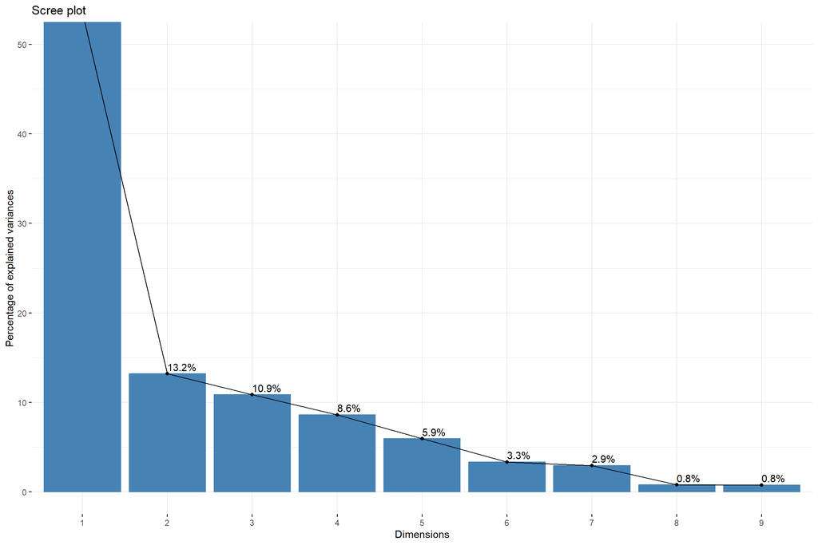

## Contibution

Variables are displayed together with their percentage contributions to each principle component in the principal component analysis bar plots. Aerial dry weight, leaf area, fresh aerial weight, leaf breadth, and root lengths contribute more in the first dimension, and in the second, leaf length and root dry weight are more important. As a result, we can infer that these characteristics may be crucial for describing plant stress.

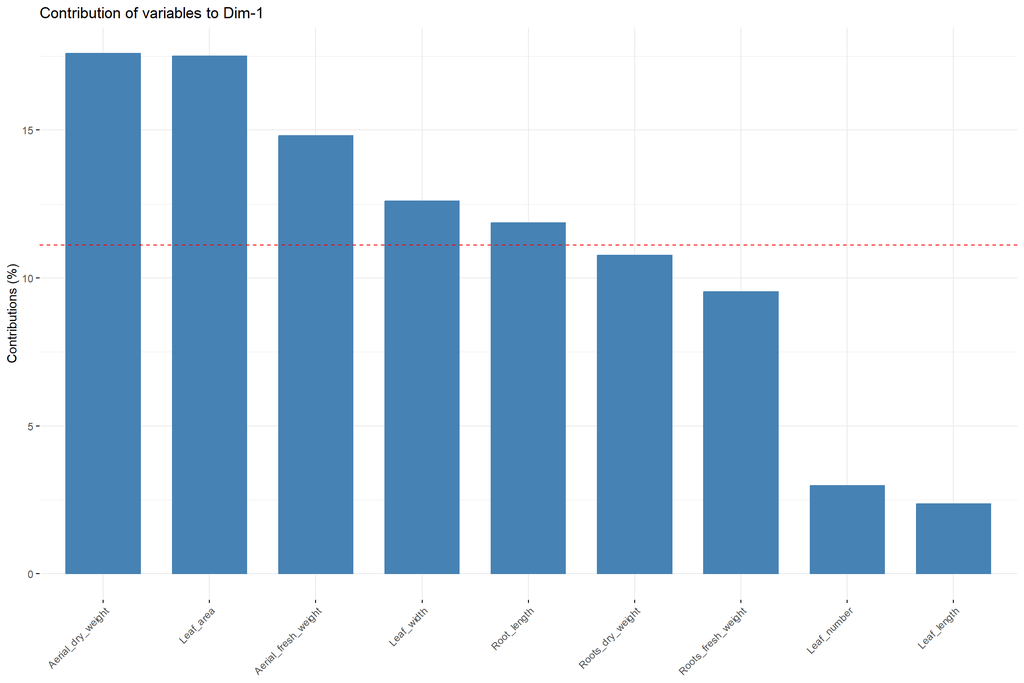

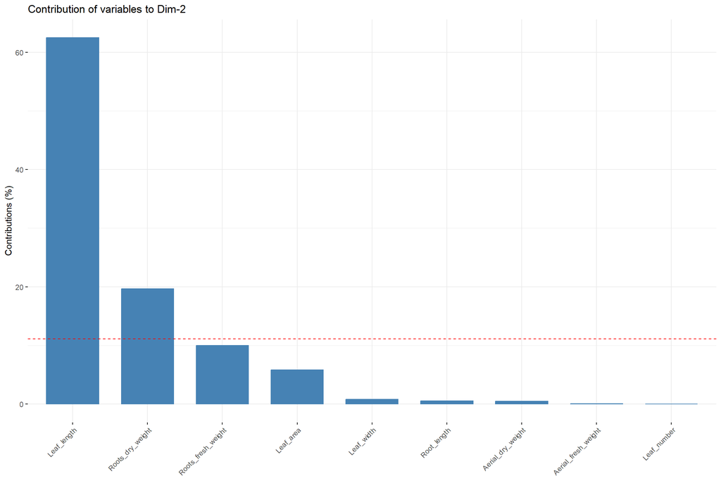

## PCA Biplot

To find the key factors that best explain the changes in the data, a Principal Component Analysis biplot was created. These are the groups of observations that share a common trait. The many species are represented by the points. The lines with greater lengths are the ones that are primarily responsible for the species’ variation. The biplot demonstrates how the species varies as a result of several parameters. Different species exhibit their responses to water stress in different ways. For instance, Hordeum vulgare differs primarily as a result of the leaf length.

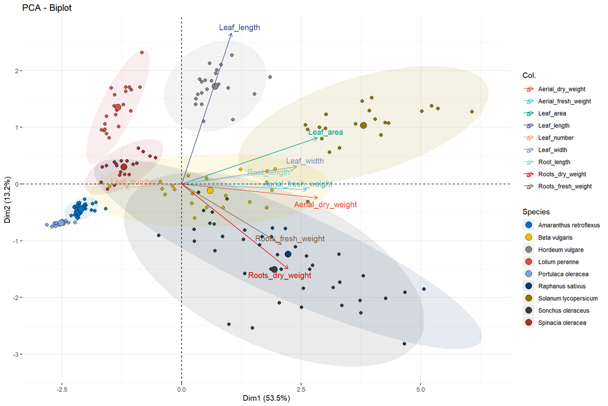

## Cluster Analysis

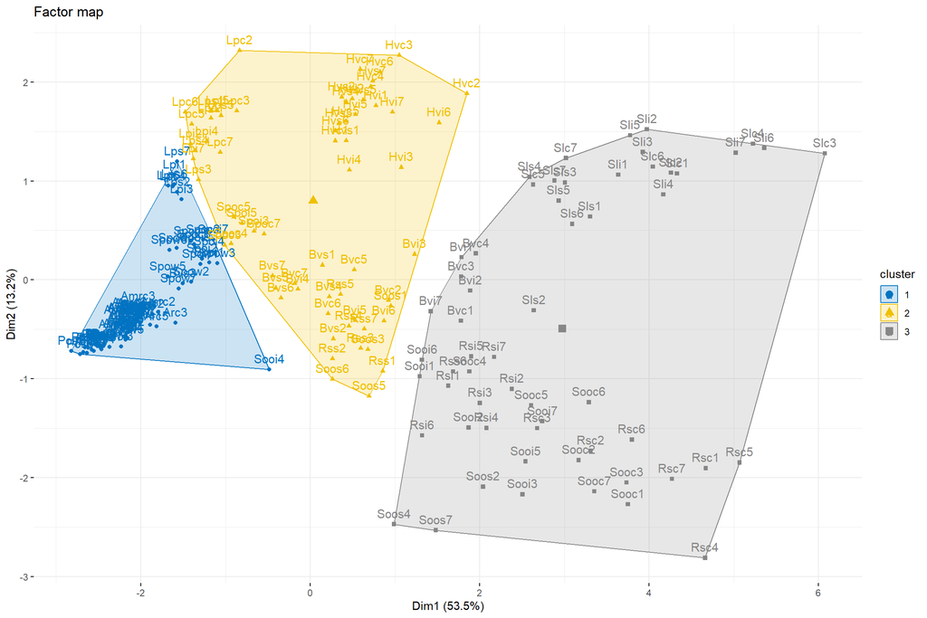

```
## $`1`
##                         v.test Mean in category Overall mean sd in category
## Leaf_number           5.347200      13.49878298   11.1018768     6.45828599
## Roots_fresh_weight   -6.305440       0.05781609    1.4114286     0.06883973
## Leaf_width           -6.484251       1.63400472    4.3145639     0.98675817
## Leaf_length          -7.357696       7.42883296   14.9371832     6.94554959
## Roots_dry_weight     -8.126645       0.01145977    0.1903238     0.03283389
## Aerial_fresh_weight  -8.679526       1.51701149    6.4214762     1.43612034
## Aerial_dry_weight    -9.625577       0.10172414    0.5798571     0.10870404
## Leaf_area           -10.334543       4.45536369   29.8694602     4.44202016
## Root_length         -10.904383       5.91568966   16.0425333     3.80004127
##                     Overall sd      p.value
## Leaf_number          5.4501044 8.932526e-08
## Roots_fresh_weight   2.6101120 2.873757e-10
## Leaf_width           5.0262699 8.917384e-11
## Leaf_length         12.4074598 1.871111e-13
## Roots_dry_weight     0.2676036 4.413367e-16
## Aerial_fresh_weight  6.8703018 3.974214e-18
## Aerial_dry_weight    0.6039517 6.235609e-22
## Leaf_area           29.8994779 4.917495e-25
## Root_length         11.2915415 1.098363e-27
##
## $`2`
##                       v.test Mean in category Overall mean sd in category
## Leaf_length         7.600593       24.6800000    14.937183     13.8505451
## Root_length         3.734479       20.3990308    16.042533      9.3050744
## Roots_fresh_weight -2.117945        0.8403077     1.411429      0.7489233
## Leaf_number        -2.476060        9.7076923    11.101877      4.3135674
## Leaf_width         -3.224792        2.6400000     4.314564      1.9856640
##                    Overall sd      p.value
## Leaf_length         12.407460 2.947767e-14
## Root_length         11.291542 1.881040e-04
## Roots_fresh_weight   2.610112 3.417971e-02
## Leaf_number          5.450104 1.328411e-02
## Leaf_width           5.026270 1.260642e-03
##
## $`3`
##                        v.test Mean in category Overall mean sd in category
## Aerial_dry_weight   11.532974        1.3598276    0.5798571      0.5295264
## Aerial_fresh_weight 10.676482       14.6351724    6.4214762      6.4604121
## Leaf_width          10.478228       10.2120690    4.3145639      6.0737444
## Roots_dry_weight    10.472391        0.5041379    0.1903238      0.2919969
## Leaf_area           10.129276       63.7832759   29.8694602     28.0812135
## Roots_fresh_weight   9.136789        4.0818966    1.4114286      3.7128943
## Root_length          8.152407       26.3505172   16.0425333      7.8476518
## Leaf_number         -3.331033        9.0689655   11.1018768      3.0335030
##                     Overall sd      p.value
## Aerial_dry_weight    0.6039517 8.998054e-31
## Aerial_fresh_weight  6.8703018 1.311481e-26
## Leaf_width           5.0262699 1.087620e-25
## Roots_dry_weight     0.2676036 1.156834e-25
## Leaf_area           29.8994779 4.096722e-24
## Roots_fresh_weight   2.6101120 6.433435e-20
## Root_length         11.2915415 3.567520e-16
## Leaf_number          5.4501044 8.652433e-04
```

# Anova analysis and Result

```
## [1] "character"
```

```
## [1] "character"
```

## Boxplot showing the results of the Anova

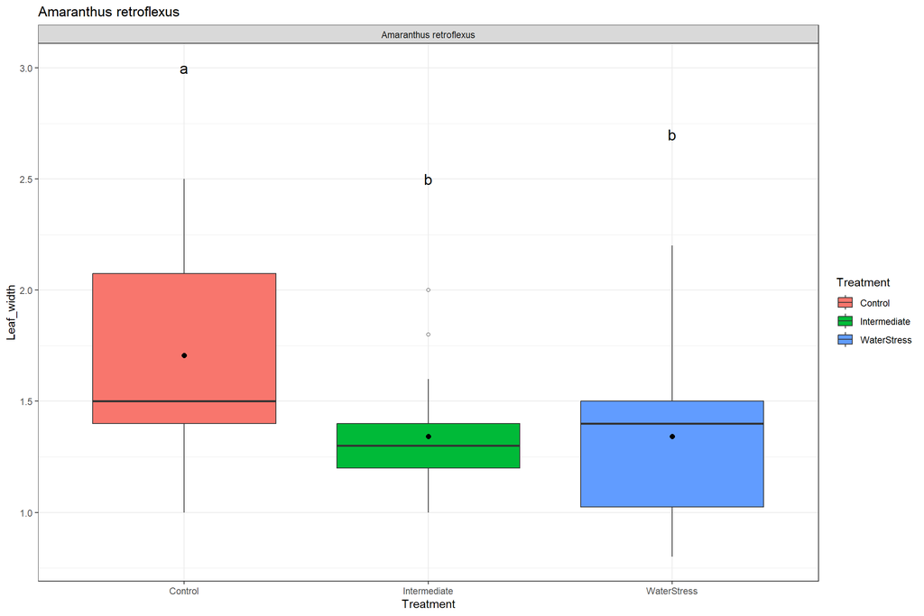

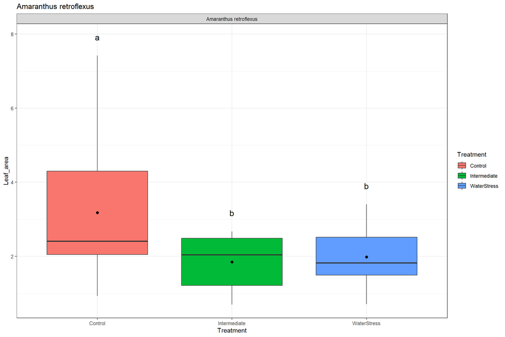

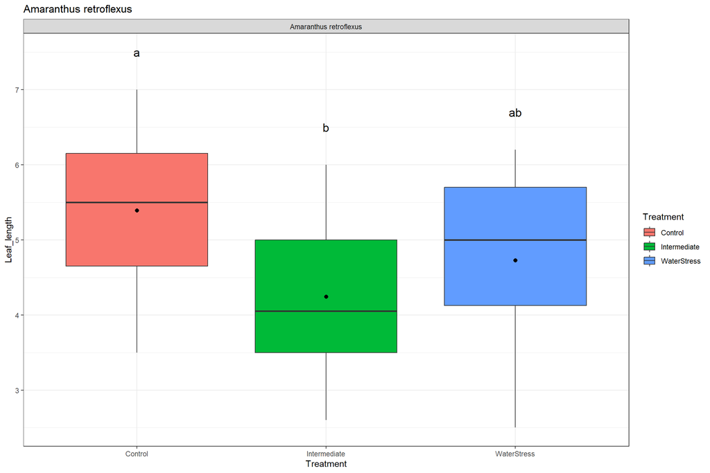

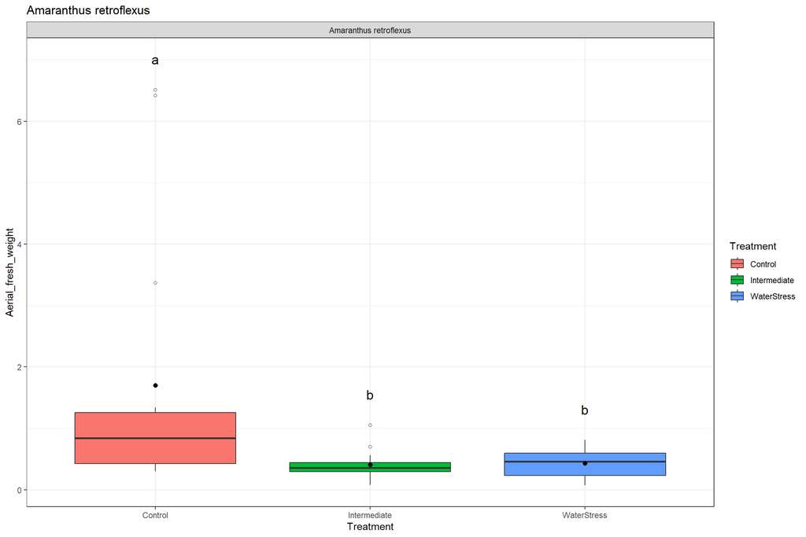

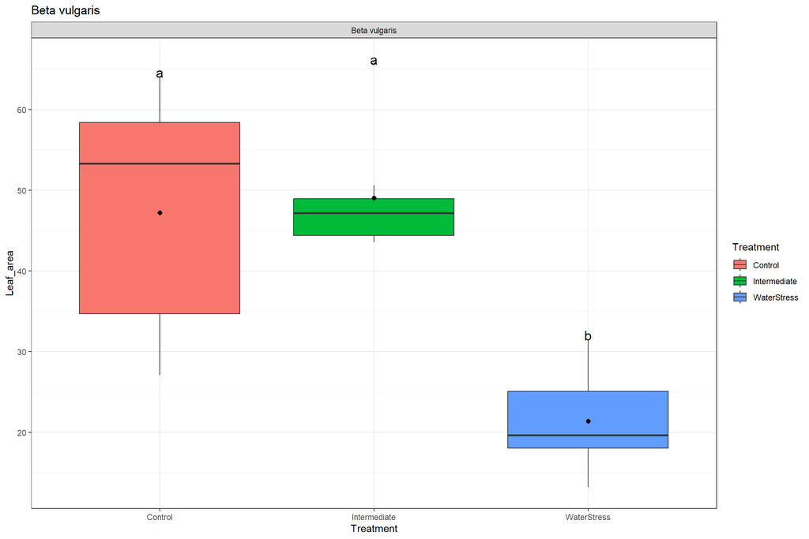

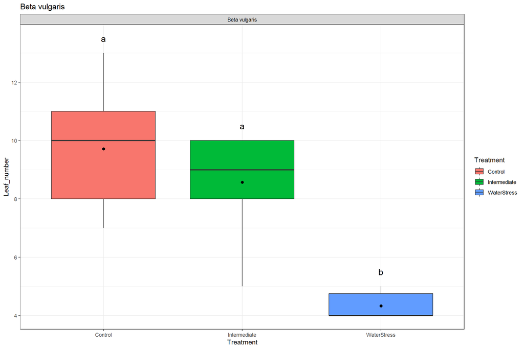

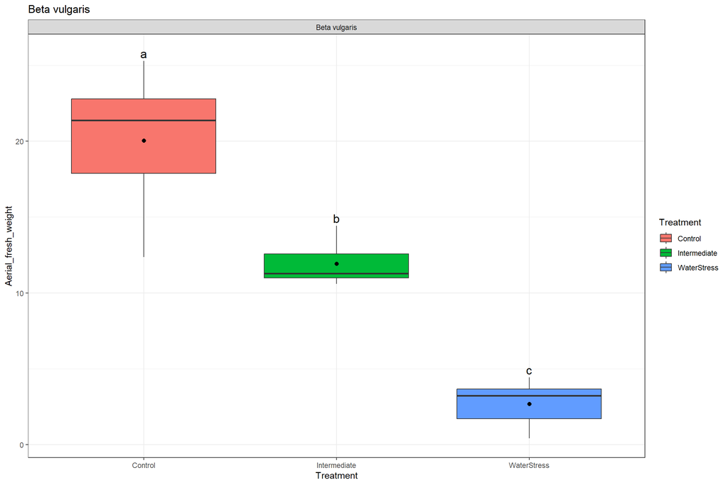

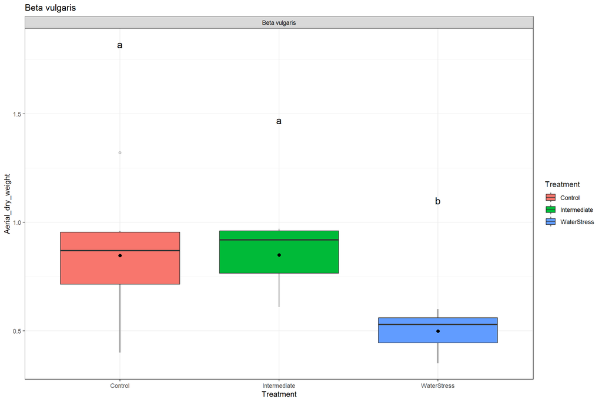

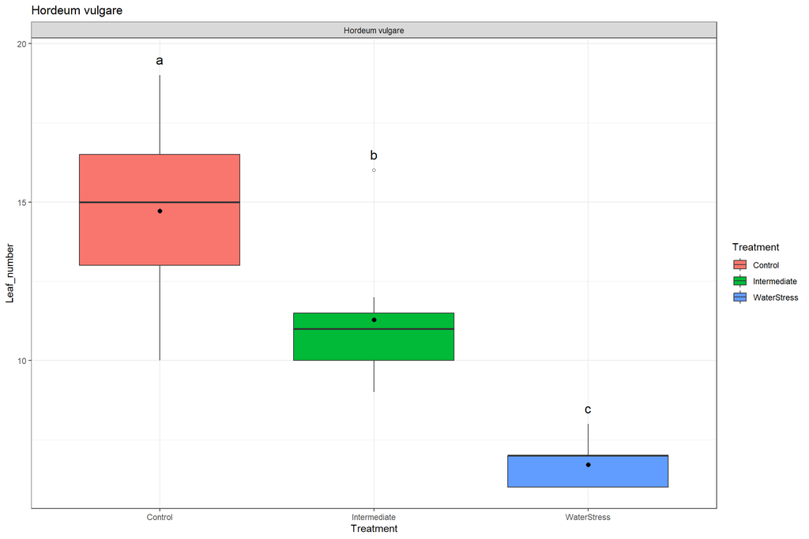

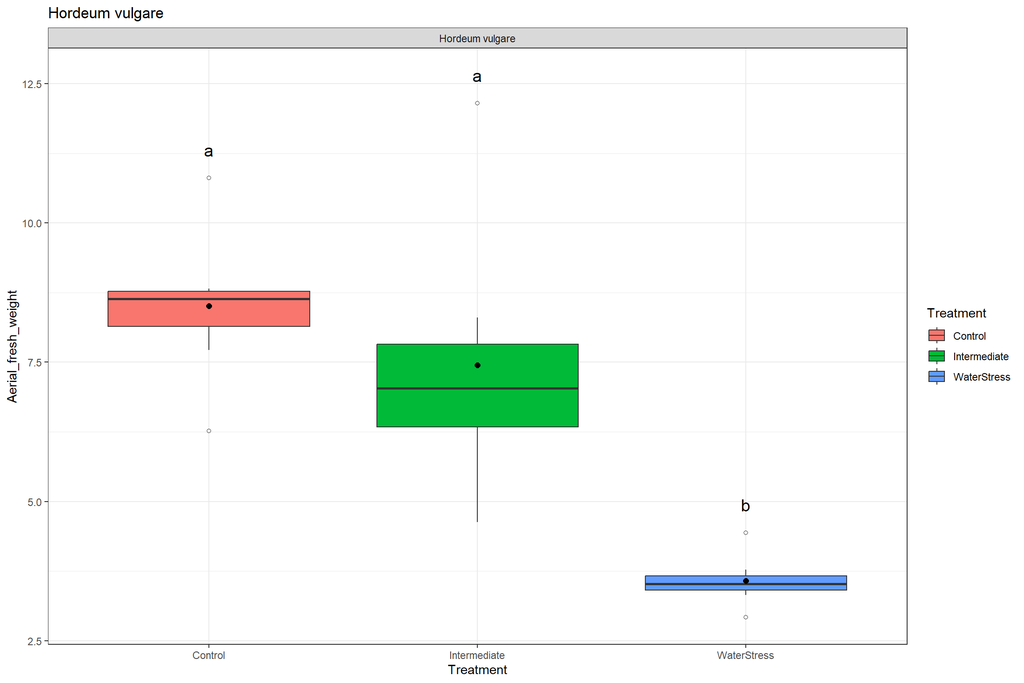

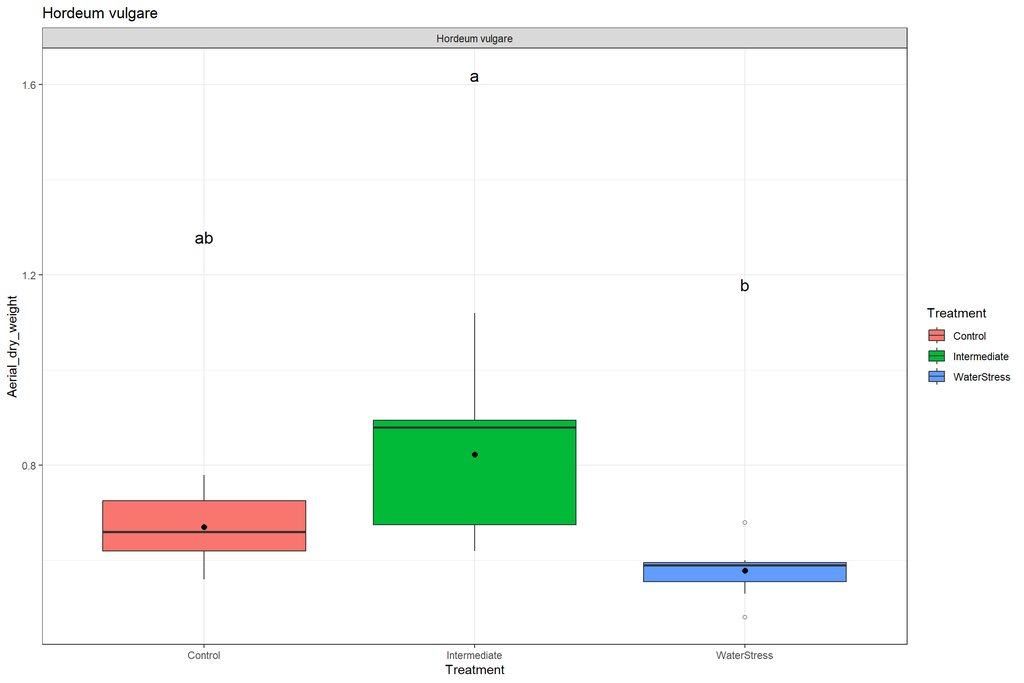

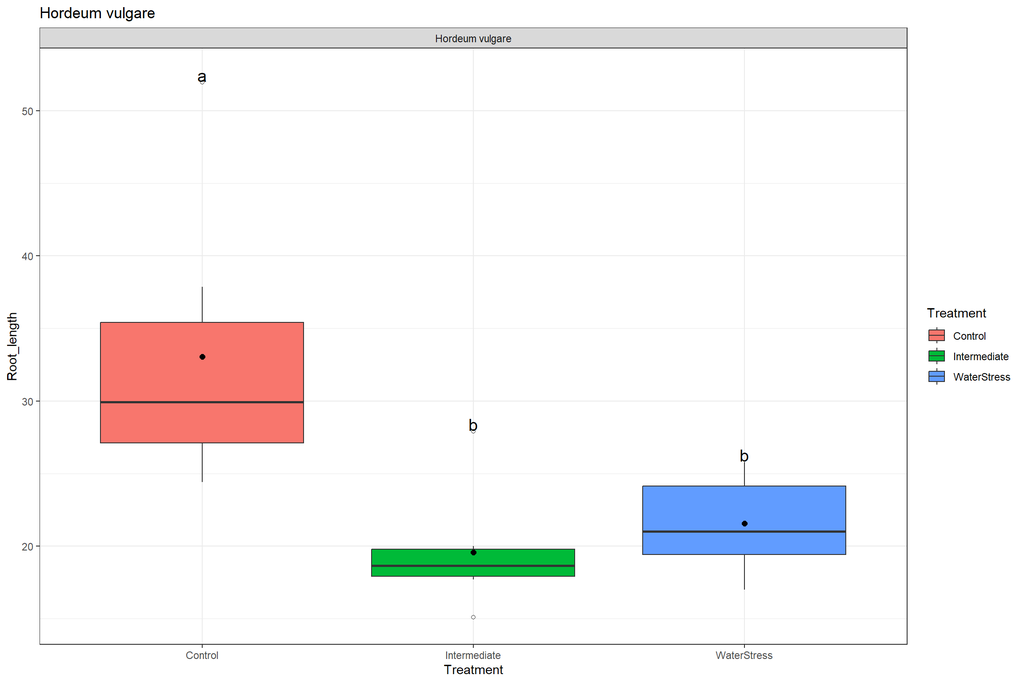

[33 more figures not shown]

# Correlation Between Soil humidity and Electrical conductivity

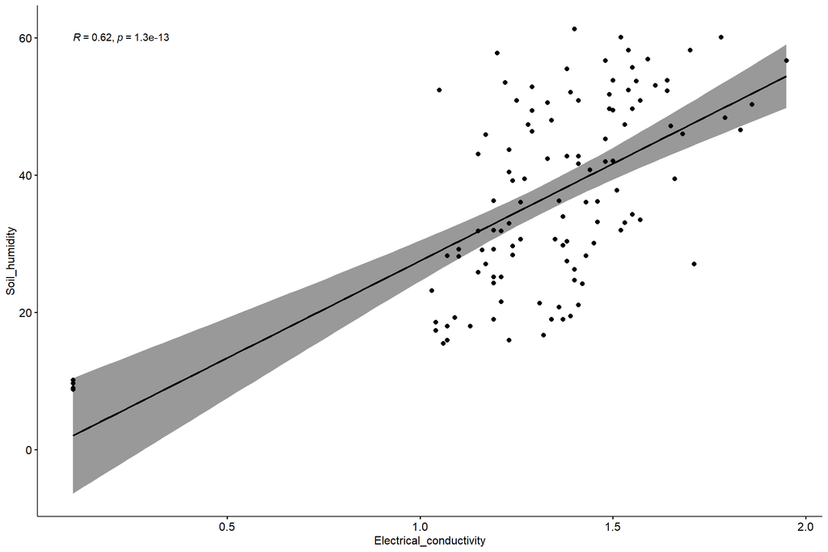

# Conclusion

For all the same conditions, not all species react to water stress in the same way. Consequently, various parameters are required for the evaluation to explain their response. From the cluster analysis, the parameters measured from the root and the leaf like root length, leaf length, and root weight are the most important variable defining clusters for most of the species, and may therefore can be used in future studies of plant response to water stress. In most species, leaf area, aerial fresh weight, and aerial dry weight play significant roles in predicting how they will react to the treatment The treatments are more significant in crop species compared to weed species, indicating that cultivated plants are more susceptible to the water stress than weeds.

# References

Picón-Toro, J., González-Dugo, V., Uriarte, D., Mancha, L., & Testi, L. (2012). Effects of canopy size and water stress over the crop coefficient of a “Tempranillo” vineyard in south-western Spain. Irrigation Science, 30(5), 419-432. doi:10.1007/s00271-012-0351-3 Zhang, J., Sha, Z., Zhang, Y., Bei, Z., & Cao, L. (2015). The effects of different water and nitrogen levels on yield, water and nitrogen utilization efficiencies of spinach ( Spinacia oleracea L.). Canadian Journal of Plant Science, 95(4), 671–679. doi:10.4141/cjps-2014-184 Ramezanifar, H., Yazdanpanah, N., Golkar Hamzee Yazd, H., Tavousi, M., & Mahmoodabadi, M. (2022). Spinach Growth Regulation Due to Interactive Salinity, Water, and Nitrogen Stresses. Journal of Plant Growth Regulation, 41(4), 1654–1671.doi:10.1007/s00344-021-10407-1 Jangpromma, N., Songsri, P., Thammasirirak, S., & Jaisil, P. (2010). Rapid assessment of chlorophyll content in surgarcane using a SPAD chlorophyll meter across different water stress conditions. Asian Journal of Plant Sciences, 9(6), 368-374. doi:10.3923/ajps.2010.368.374 Hasanuzzaman, M., Shabala, L., Brodribb, T. J., Zhou, M., & Shabala, S. (2022). Understanding the role of physiological and agronomical traits during drought recovery as a determinant of differential drought stress tolerance in barley. Agronomy, 12(9).doi: 10.3390/agronomy12092136